# The Impact of Technology Access on Earnigs

Group 06

Febrary 23, 2019

# 0. Research Question and Variable Selection

**Research Questions:**

With a past of racial inequality in the southern states it would be interesting to examine how race/ethnicity is related to access to the internet and other technologies and how not having or having access could effect a persons earnings. This can be explored via the following research questions:

1. In the state of Alabama, how to earnings vary by access to the internet/technology?
2. Does the internet/technology premium vary by race and ethnicity?

**Variable Selection**:

To answer the research questions, this study looks at the variables which will reveal the demographic characteristics - such as “age” or “race”; socioeconomic status - such as “employment status” or “wage”; and the access to technology - such as “access to internet.”

- The following variables will be included in this study. (Some other variables will be used as connector when joining tables but will not be included in the final data frame.)
  1. AGEP # Age: 0~99
  2. SEMP # Self-employment income past 12 months (signed)
  3. WAGP # Wages or salary income past 12 months
  4. HISP # Recoded detailed Hispanic origin
  5. NATIVITY # Nativity
  6. PERNP # Total person’s earnings
  7. RAC1P # Recoded detailed race code
  8. RACAIAN # American Indian and Alaska Native recode
  9. RACASN # Asian recode
  10. RACBLK # Black or African American recode
  11. RACNH # Native Hawaiian recode
  12. RACWHT # White recode
  13. SCHL # Educational attainment
  14. WAOB # World area of birth
  15. WKW #Weeks worked during past 12 months
  16. ACCESS # Access to the Internet

# 1. System Setup

One external function was programmed by the team. It is located at folder of “code”, and the function is: 1. function_convert_CSV_to_vector.R

```r
# Clear environment
rm(list = ls(all = TRUE))

# check if package is installed, if not installed then load
if(!require(here)){
  install.packages("here")
}
library(here)

if(!require(tidyverse)){
  install.packages("tidyverse")
}
library(tidyverse)

if(!require(lmtest)){
  install.packages("lmtest")
}
library(lmtest)

if(!require(scales)){
  install.packages("scales")
}
library(scales)

if(!require(sjPlot)){
  install.packages("sjPlot")
}
library(sjPlot)

if(!require(sjmisc)){
  install.packages("sjmisc")
}
library(sjmisc)

if(!require(sjlabelled)){
  install.packages("sjlabelled")
}
library(sjlabelled)

source(here("code","function_convert_CSV_to_vector.R"))
```

# 2. Data Wrangling

## 2.1 Import and merge the raw data

```r
#load the persional data to variable Base
base <- read_csv(here('raw_data','ss16pal.csv'))%>%
  select(SERIALNO, #Serial Number to link House Hold and Personal data
         AGEP,  # Age: 0#99
         SEMP,  # Self-employment income past 12 months (signed)
         WAGP,  # Wages or salary income past 12 months
         HISP,  # Recoded detailed Hispanic origin
         NATIVITY,  # Nativity
         PERNP, # Total person's earnings
         RAC1P, # Recoded detailed race code
         RACAIAN, # American Indian and Alaska Native recode
         RACASN,  # Asian recode
         RACBLK,  # Black or African American recode
         RACNH, # Native Hawaiian recode
         RACWHT,  # White recode
         SCHL,   # Educational attainment
         SEX,     # SEX
         WAOB,  # World area of birth
         WKW)   #Weeks worked during past 12 months

#import the house hold data
househould <- read_csv(here('raw_data','ss16hal.csv'))%>%
  select(SERIALNO, #Serial Number to link House Hold and Personal data
        ACCESS # Access to the Internet
  )
base <- base %>% left_join(househould) %>% select(-SERIALNO)
rm(househould)
```

## 2.2 Convert the variable types

Convert the categorical data into factor type and numerical data into numeric type. The factorial data in this data frame will keep its representative code instead of the category name to save the memory space.

```r
#conver the catagorical variable type
base <- base %>% mutate(HISP= as.factor(HISP),
                        RAC1P= as.factor(RAC1P),
                        RACAIAN = as.factor(RACAIAN),
                        RACASN = as.factor(RACASN),
                        RACBLK = as.factor(RACBLK),
                        RACNH = as.factor(RACNH),
                        RACWHT = as.factor(RACWHT),
                        SEX = as.factor(SEX),
                        WAOB = as.factor(WAOB),
                        WKW = as.factor(WKW),
                        ACCESS = as.factor(ACCESS),
                        NATIVITY = as.factor(NATIVITY)
                        )

#conver the numeric variable type
base <- base %>% mutate(AGEP = as.numeric(AGEP),
                        SEMP= as.numeric(SEMP),
                        WAGP= as.numeric(WAGP),
                        PERNP= as.numeric(PERNP),
                        SCHL = as.numeric(SCHL)
                        )
```

# 3. Criteria for subsetting

To answer the research questions, three criteria are applied:

1. The age should be between 14 and 62 years old. (This legal age for starting work and the retirement.)
2. The earning should be a positive number. (negative earning does not make sense)
3. The annual working weeks should be at least 40 hours. (People working less than 40 weeks a year are considered as part-time employee. )

**1. Age range:**

The ages of cases covered in the survey are ranging from **0 year old to 93 years old**. There is **no missing value** under the age category.

According to the regulation from US Department of Labor, the legal working age is 14 (for most non-agricultural work), and the early retirement age is 62. This study will looks at the **age group of 14~62 years old**.

```r
base <- base %>%  filter(AGEP>=14 & AGEP <= 62)
```

**2. Earnings:**

In this study we will consider everyone that had **positive earnings** in the last 12 months.

```r
base <- base %>%  filter(WAGP > 0)
```

**3. Annually Working Weeks:**

The selection of full time employee is arbitrary. This study includes groups which **work more than 40 weeks a years**. (Please be noted: More studies should be considered in deciding the threshold separating full-time and part-time employee. This study set the 40 week/year as the threshold for now.)

```r
base <- base %>%
         filter(WKW %in% c("50 to 52 weeks worked during past 12 months", "48 to 49 weeks worked during past 12 months", "40 to 47 weeks worked during past 12 months"))
```

# 4. Building Models

## 4.1 Brief of Internet Access Variable

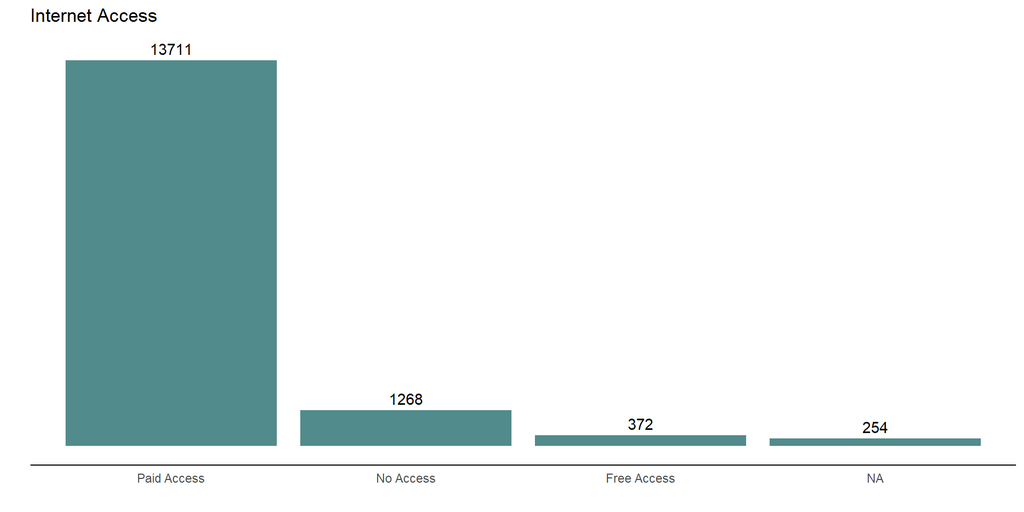

```r
base %>%
  group_by(ACCESS) %>%
  summarise(count = n()) %>%
  ggplot(aes(x = reorder(ACCESS, -count), y = count)) +
  geom_bar(stat = "identity" , fill = "darkslategray4") +
  geom_text(aes(label = count), vjust = -0.5) +
  theme_classic() +
  theme(axis.line.y = element_blank(), axis.text.y = element_blank(), axis.ticks = element_blank()) +
  xlab("") +
  ylab("") +
  ggtitle("Internet Access") +
  ylim(c(0,14000))
```

```r
ggsave("internec_access.png")
```

| Internet Access | Counts |
| --- | --- |
| Paid | 13711 |
| No | 1268 |
| Free | 372 |
| N/A | 254 |

## 4.1 Examine access to the internet and its relation to wage.

**- Relationship between Internet Access to Wage**

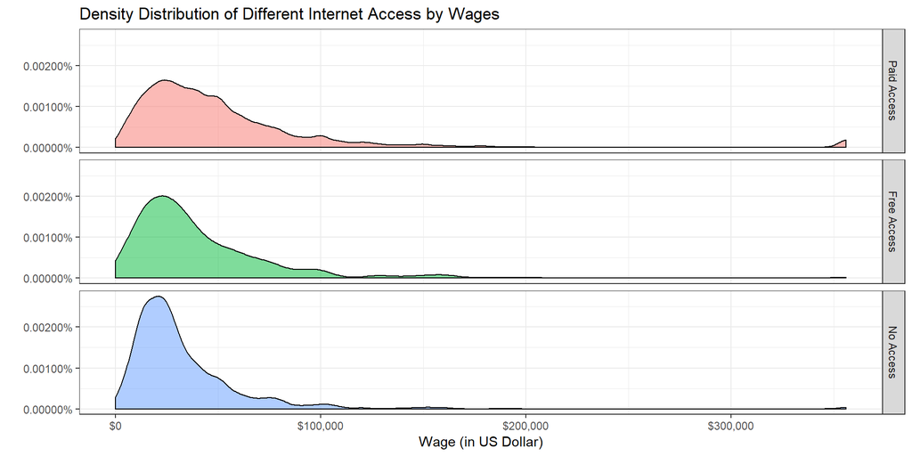

```r
base %>%
  filter(!is.na(ACCESS)) %>%
  ggplot(aes(x = WAGP, fill = ACCESS)) +
  geom_density(alpha = 0.5) +
  theme_bw() +
  scale_color_brewer(palette="Accent") +
  scale_x_continuous(labels = dollar)+
  scale_y_continuous(labels = percent) +
  theme(legend.position="none") +
  facet_grid(ACCESS ~ .) +
  labs(title = "Density Distribution of Different Internet Access by Wages") +
  xlab("Wage (in US Dollar)") +
  ylab("")
```

```r
ggsave("density_wage.png")
```

## 4.2 Building the model

- Prepare the data frame for models.
  - Sub-setting the data by removing the “Paid Access” and “N/A”
  - Categorize the “SCHL” variable as :
    - Low_education - less than the Grade 4 (include Grade 4)
    - some_educatoin - from Grade 5 to Grade 11 (include Grade 11)
    - high_school - 12th grade - no diploma, and Regular high school diploma
    - undergrad_or_higher - GED or alternative credential, to Doctor Degree

```r
base_model <- base %>%
  filter(!is.na(ACCESS) & ACCESS != "Paid Access") %>%
  mutate(free_access = ACCESS == "Free Access",
         hispanic = HISP != "Not Spanish/Hispanic/Latino",
         black = RACBLK == "Yes",
         female = SEX =="Female",
         white = hispanic == FALSE & black == FALSE,
         low_education = as.integer(SCHL) <= 7,
         some_education = as.integer(SCHL) > 7 & as.integer(SCHL) <= 14,
         high_school = as.integer(SCHL) > 14 & as.integer(SCHL) <= 16,
         undergrad_or_higher = as.integer(SCHL) > 16,
         age = AGEP,
         age_square = AGEP^2
         )
```

## 4.2.1 Model 1

- Single variate regression (wage - free_access)

```r
model_01 <- lm(WAGP ~ free_access, data = base_model)
summary(model_01)
```

```
##
## Call:
## lm(formula = WAGP ~ free_access, data = base_model)
##
## Residuals:
##    Min     1Q Median     3Q    Max
## -38618 -17565  -7565   7435 323435
##
## Coefficients:
##                 Estimate Std. Error t value Pr(>|t|)
## (Intercept)      32564.9      880.2  36.999  < 2e-16 ***
## free_accessTRUE   7653.4     1848.0   4.141 3.63e-05 ***
## ---
## Signif. codes:  0 '***' 0.001 '**' 0.01 '*' 0.05 '.' 0.1 ' ' 1
##
## Residual standard error: 31340 on 1638 degrees of freedom
## Multiple R-squared:  0.01036,    Adjusted R-squared:  0.009758
## F-statistic: 17.15 on 1 and 1638 DF,  p-value: 3.628e-05
```

## 4.2.2 Model 2

- Multivariate regression (wage ~ free_access + hispanic + blace + female + some_education + high_school + undergrad_or_higher)

```r
model_02 <- lm(WAGP ~ free_access + hispanic + black + female + some_education + high_school + undergrad_or_higher, data = base_model)
summary(model_02)
```

```
##
## Call:
## lm(formula = WAGP ~ free_access + hispanic + black + female +
##     some_education + high_school + undergrad_or_higher, data = base_model)
##
## Residuals:
##    Min     1Q Median     3Q    Max
## -47963 -15864  -6072   7205 336381
##
## Coefficients:
##                         Estimate Std. Error t value Pr(>|t|)
## (Intercept)                39974       5023   7.959 3.23e-15 ***
## free_accessTRUE             5682       1822   3.119  0.00185 **
## hispanicTRUE               -2974       3612  -0.823  0.41052
## blackTRUE                  -4187       1594  -2.626  0.00872 **
## femaleTRUE                -13176       1524  -8.646  < 2e-16 ***
## some_educationTRUE         -7715       5352  -1.441  0.14966
## high_schoolTRUE            -2992       5092  -0.588  0.55687
## undergrad_or_higherTRUE     6708       5092   1.317  0.18795
## ---
## Signif. codes:  0 '***' 0.001 '**' 0.01 '*' 0.05 '.' 0.1 ' ' 1
##
## Residual standard error: 30250 on 1632 degrees of freedom
## Multiple R-squared:  0.08143,    Adjusted R-squared:  0.07749
## F-statistic: 20.67 on 7 and 1632 DF,  p-value: < 2.2e-16
```

## 4.2.3 BPG test for Model 1 and Model 2

- BPG test for Model 1
  - The P-value for the BPG test for model 1 was 0.3096. It fails to reject null hypothesis of homoscedasticity.

```r
bptest(model_01)
```

```
##
##  studentized Breusch-Pagan test
##
## data:  model_01
## BP = 1.0322, df = 1, p-value = 0.3096
```

```r
bptest(model_02)
```

```
##
##  studentized Breusch-Pagan test
##
## data:  model_02
## BP = 14.304, df = 7, p-value = 0.04603
```

## 4.2.4 Findings (Model_1&2)

```r
tab_model(model_01, model_02,  dv.labels = c("Model_1", "Model_2"))
```

|  | Model_1 |  |  | Model_2 |  |  |
| --- | --- | --- | --- | --- | --- | --- |
| Predictors | Estimates | CI | p | Estimates | CI | p |
| (Intercept) | 32564.91 | 30839.83 – 34289.98 | **<0.001** | 39973.55 | 30129.23 – 49817.86 | **<0.001** |
| free_accessTRUE | 7653.37 | 4031.30 – 11275.45 | **<0.001** | 5681.77 | 2111.44 – 9252.11 | **0.002** |
| hispanicTRUE |  |  |  | -2973.78 | -10054.13 – 4106.57 | 0.411 |
| blackTRUE |  |  |  | -4186.57 | -7311.38 – -1061.75 | **0.009** |
| femaleTRUE |  |  |  | -13175.70 | -16162.46 – -10188.94 | **<0.001** |
| some_educationTRUE |  |  |  | -7714.75 | -18205.02 – 2775.52 | 0.150 |
| high_schoolTRUE |  |  |  | -2992.15 | -12972.31 – 6988.02 | 0.557 |
| undergrad_or_higherTRUE |  |  |  | 6707.85 | -3273.23 – 16688.93 | 0.188 |
| Observations | 1640 |  |  | 1640 |  |  |
| R<sup>2</sup> / adjusted R<sup>2</sup> | 0.010 / 0.010 |  |  | 0.081 / 0.077 |  |  |

**Findings:**

1. BPG test.
- Model 1 fails to reject the null hypothesis of homoscedasticity.
- Model 2 rejects the null hypothesis of homoscedasticity at significance level of 5%.
2. Comparing with “No Internet Access”, people with “Free Internet Access” will earn 7653.37 dollar a year as wage.
3. Comparing the Model 1 to Model 2, the premium of “Free Internet Access” drops from 7653.37 dollar a year to 5681.77 dollar a year. One possibile explanation was that the model 2 includes the dummy variable of “undergrad_or_higher” which indicates the people with college or higher education have access to free internect servie, and also benefit from the internect service.

## 4.2.5 Model 3

- Single variate regression (log(wage) ~ free_access)

```r
base_model <- base_model %>% mutate(ln_earnings = log(WAGP))
model_03 <- lm(ln_earnings ~ free_access, data = base_model)

summary(model_03)
```

```
##
## Call:
## lm(formula = ln_earnings ~ free_access, data = base_model)
##
## Residuals:
##     Min      1Q  Median      3Q     Max
## -5.5165 -0.4666  0.0050  0.4750  2.6610
##
## Coefficients:
##                 Estimate Std. Error t value Pr(>|t|)
## (Intercept)     10.12166    0.02137 473.616  < 2e-16 ***
## free_accessTRUE  0.17780    0.04487   3.962 7.74e-05 ***
## ---
## Signif. codes:  0 '***' 0.001 '**' 0.01 '*' 0.05 '.' 0.1 ' ' 1
##
## Residual standard error: 0.761 on 1638 degrees of freedom
## Multiple R-squared:  0.009494,   Adjusted R-squared:  0.008889
## F-statistic:  15.7 on 1 and 1638 DF,  p-value: 7.741e-05
```

## 4.2.6 Model 4

- Multivariate regression (log(wage） ~ free_access + hispanic + blace + female + age + age-square)

```r
model_04 <- lm(ln_earnings ~ free_access + hispanic + black + female + AGEP + I(AGEP^2), data = base_model)
summary(model_04)
```

```
##
## Call:
## lm(formula = ln_earnings ~ free_access + hispanic + black + female +
##     AGEP + I(AGEP^2), data = base_model)
##
## Residuals:
##     Min      1Q  Median      3Q     Max
## -5.5816 -0.3774  0.0161  0.4305  2.9749
##
## Coefficients:
##                   Estimate Std. Error t value Pr(>|t|)
## (Intercept)      8.4976362  0.2053326  41.385  < 2e-16 ***
## free_accessTRUE  0.2035999  0.0417832   4.873 1.21e-06 ***
## hispanicTRUE    -0.0566347  0.0834816  -0.678    0.498
## blackTRUE       -0.1639664  0.0370955  -4.420 1.05e-05 ***
## femaleTRUE      -0.3200655  0.0351072  -9.117  < 2e-16 ***
## AGEP             0.0772542  0.0104623   7.384 2.44e-13 ***
## I(AGEP^2)       -0.0007426  0.0001250  -5.941 3.46e-09 ***
## ---
## Signif. codes:  0 '***' 0.001 '**' 0.01 '*' 0.05 '.' 0.1 ' ' 1
##
## Residual standard error: 0.7027 on 1633 degrees of freedom
## Multiple R-squared:  0.1579, Adjusted R-squared:  0.1548
## F-statistic: 51.05 on 6 and 1633 DF,  p-value: < 2.2e-16
```

## 4.2.7 BPG test for Model 3 and Model 4

- BPG test for Model 3
  - The P-value for the BPG test for model 3 was 0.2341. It fails to reject null hypothesis of homoscedasticity.

```r
bptest(model_03)
```

```
##
##  studentized Breusch-Pagan test
##
## data:  model_03
## BP = 1.4159, df = 1, p-value = 0.2341
```

- BPG test for Model 4
  - The P-value for the BPG test for model 4 was 0.5837. It fails to reject null hypothesis of homoscedasticity.

```r
bptest(model_04)
```

```
##
##  studentized Breusch-Pagan test
##
## data:  model_04
## BP = 4.6936, df = 6, p-value = 0.5837
```

## 4.2.8 Findings (Model_3&4)

```r
tab_model(model_03, model_04,  dv.labels = c("Model_3", "Model_4"))
```

|  | Model_3 |  |  | Model_4 |  |  |
| --- | --- | --- | --- | --- | --- | --- |
| Predictors | Estimates | CI | p | Estimates | CI | p |
| (Intercept) | 10.12 | 10.08 – 10.16 | **<0.001** | 8.50 | 8.10 – 8.90 | **<0.001** |
| free_accessTRUE | 0.18 | 0.09 – 0.27 | **<0.001** | 0.20 | 0.12 – 0.29 | **<0.001** |
| hispanicTRUE |  |  |  | -0.06 | -0.22 – 0.11 | 0.498 |
| blackTRUE |  |  |  | -0.16 | -0.24 – -0.09 | **<0.001** |
| femaleTRUE |  |  |  | -0.32 | -0.39 – -0.25 | **<0.001** |
| AGEP |  |  |  | 0.08 | 0.06 – 0.10 | **<0.001** |
| I(AGEP^2) |  |  |  | -0.00 | -0.00 – -0.00 | **<0.001** |
| Observations | 1640 |  |  | 1640 |  |  |
| R<sup>2</sup> / adjusted R<sup>2</sup> | 0.009 / 0.009 |  |  | 0.158 / 0.155 |  |  |

**Findings:**

1. BPG test.
- Both Model 3 and Model 4 fails to reject the null hypothesis of homoscedasticity.
2. Comparing with “No Internet Access”, the “Free Internet Access” will allow people extra 18% in annual wage.
3. Comparing the Model 3 to Model 4, the premium of “Free Internet Access”, to the “No Internet Access”, increase from “18% of annual wage” to “20% of annual wage.” One possibile explanation was that the model 4 includes the variabel of age, the premium of free internet decrease with the age growth.
4. ( **Guys, I do not know how to interpretate the age, especially the coefficient of age suqare is negative zero. Shoot! How should I understand it?** )

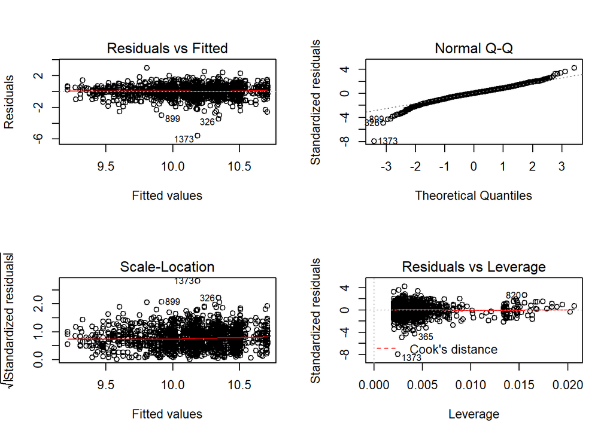

```r
par(mfrow = c(2, 2))
plot(model_04)
```

**Diagnostics of Model_04 Log Earnings**

**Breusch_Pagan Test**

- Since the p-value is > 0.05 we fail to reject the null hypothesis of homoskedasticity.

**Residuals vs Fitted Plot.**

- The line is horizontal and there is no distinct patterns, indicating a linear relationship.

**Normal Q-Q**

**Scale-Location**

- Since the line is close to horizontal and based on our BP test we can see that we do not have a heteroscedasticity problem with this model.